# Neural Network Hyperparameter Tuning

#### This notebook complements the Modeling notebook, and is dedicated to the Feedforward Neural Network hyperparameter tuning. The parameters of the best performing model generated by this notebook will serve as a the foundation for the final model configuration in the Modeling notebook.

### Import Libraries

```python
import warnings
warnings.filterwarnings('ignore')

import pandas as pd
import numpy as np
import matplotlib.pyplot as plt
import plotly.express as px
import seaborn as sns
import pyarrow.parquet as pq
import pyarrow as pa
```

```python
from sklearn.model_selection import ParameterGrid
from sklearn.model_selection import KFold
from keras.models import Sequential
from keras.layers import Dense
from keras.optimizers import SGD
from keras.callbacks import EarlyStopping
from sklearn.utils import shuffle
from sklearn.metrics import roc_auc_score
```

**Read train and test datasets**

```python
X_train_resampled = pd.read_parquet('./data_treated/X_train_resampled.parquet')
y_train_resampled = pd.read_parquet('./data_treated/y_train_resampled.parquet')

X_test = pd.read_parquet('./data_treated/X_test.parquet')
y_test = pd.read_parquet('./data_treated/y_test.parquet')
```

```python
np.mean(y_train_resampled)
```

```
isClick    0.239783
dtype: float64
```

```python
np.mean(y_test)
```

```
isClick    0.049563
dtype: float64
```

### Neural Network Hyperparameter Tuning

In this section, we delve into an investigation of hyperparameters to enhance the efficiency of a neural network. The hyperparameters under consideration include the number of training epochs, batch size, hidden layer count, and the quantity of neurons within each layer. We specifically limit the exploration of layer counts to 1, 2, and 3, while varying the number of neurons per layer across 5, 10, and 15. The rationale behind constraining the layer and neuron count lies in recognizing the inherent simplicity of the input features. As most of the input features are binary variables derived from categorical variables through one-hot encoding, a sophisticated neural network architecture is deemed unnecessary. Consequently, our focus remains on a selection of modest architectures to strike a balance between model expressiveness and computational efficiency.

Utilizing a grid search methodology, we systematically assess the neural network's performance across diverse combinations of hyperparameter values. This approach allows us to pinpoint the hyperparameter set that demonstrates optimal performance on the validation sets within a k-fold cross-validation framework.

Our evaluation of hyperparameter sets revolves around two performance metrics: accuracy and the area under the receiver operating characteristic curve (AUC). These metrics provide a comprehensive insight into the model's proficiency in accurately classifying observations, within both majority and minority classes.

Following the completion of the grid search, our primary aim is to identify the hyperparameter set exhibiting the highest accuracy and AUC on the validation sets within the k-fold cross-validation. This best-performing hyperparameter set will subsequently serve as the base for the final model configuration, embodying a compromise between computational efficiency and predictive accuracy.

```
Running with hyperparameters: {'batch_size': 100000, 'epochs': 20, 'layers': 1, 'learning_rate': 0.01, 'neurons': 5}
> Accuracy: 75.995, AUC: 50.000
> Accuracy: 75.991, AUC: 63.762
> Accuracy: 76.120, AUC: 50.061
> Accuracy: 75.972, AUC: 56.989
> Accuracy: 76.031, AUC: 49.999
AUC: mean=54.162 std=5.507, n=5
Accuracy: mean=76.022 std=0.053, n=5
```

```
Running with hyperparameters: {'batch_size': 100000, 'epochs': 20, 'layers': 1, 'learning_rate': 0.01, 'neurons': 10}
> Accuracy: 75.995, AUC: 63.107
> Accuracy: 75.992, AUC: 63.640
> Accuracy: 76.121, AUC: 65.249
> Accuracy: 75.972, AUC: 50.058
> Accuracy: 76.031, AUC: 64.144
AUC: mean=61.239 std=5.635, n=5
Accuracy: mean=76.022 std=0.053, n=5
```

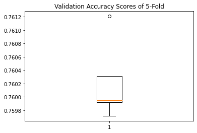

```
Running with hyperparameters: {'batch_size': 100000, 'epochs': 20, 'layers': 1, 'learning_rate': 0.01, 'neurons': 15}
> Accuracy: 75.996, AUC: 49.995
> Accuracy: 75.991, AUC: 52.778
> Accuracy: 76.120, AUC: 63.415
> Accuracy: 75.972, AUC: 57.461
> Accuracy: 76.031, AUC: 63.881
AUC: mean=57.506 std=5.556, n=5
Accuracy: mean=76.022 std=0.053, n=5
```

```
Running with hyperparameters: {'batch_size': 100000, 'epochs': 20, 'layers': 2, 'learning_rate': 0.01, 'neurons': 5}
> Accuracy: 76.019, AUC: 63.133
> Accuracy: 75.991, AUC: 65.186
> Accuracy: 76.113, AUC: 65.725
> Accuracy: 75.972, AUC: 50.000
> Accuracy: 76.031, AUC: 50.001
AUC: mean=58.809 std=7.244, n=5
Accuracy: mean=76.025 std=0.049, n=5
```

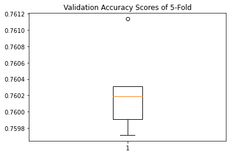

```
Running with hyperparameters: {'batch_size': 100000, 'epochs': 20, 'layers': 2, 'learning_rate': 0.01, 'neurons': 10}
> Accuracy: 75.995, AUC: 49.998
> Accuracy: 75.991, AUC: 50.000
> Accuracy: 76.120, AUC: 64.275
> Accuracy: 75.972, AUC: 63.130
> Accuracy: 76.031, AUC: 50.000
AUC: mean=55.481 std=6.723, n=5
Accuracy: mean=76.022 std=0.053, n=5
```

```
Running with hyperparameters: {'batch_size': 100000, 'epochs': 20, 'layers': 2, 'learning_rate': 0.01, 'neurons': 15}
> Accuracy: 75.995, AUC: 65.378
> Accuracy: 75.991, AUC: 63.698
> Accuracy: 76.120, AUC: 63.541
> Accuracy: 75.971, AUC: 65.517
> Accuracy: 76.032, AUC: 65.545
AUC: mean=64.736 std=0.915, n=5
Accuracy: mean=76.022 std=0.053, n=5
```

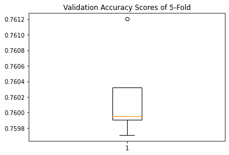

```
Running with hyperparameters: {'batch_size': 100000, 'epochs': 20, 'layers': 3, 'learning_rate': 0.01, 'neurons': 5}
> Accuracy: 75.995, AUC: 63.319
> Accuracy: 75.991, AUC: 63.840
> Accuracy: 76.120, AUC: 49.998
> Accuracy: 75.972, AUC: 64.838
> Accuracy: 76.031, AUC: 65.174
AUC: mean=61.434 std=5.757, n=5
Accuracy: mean=76.022 std=0.053, n=5
```

```
Running with hyperparameters: {'batch_size': 100000, 'epochs': 20, 'layers': 3, 'learning_rate': 0.01, 'neurons': 10}
> Accuracy: 75.995, AUC: 64.830
> Accuracy: 75.991, AUC: 64.227
> Accuracy: 76.120, AUC: 63.692
> Accuracy: 75.973, AUC: 61.103
> Accuracy: 76.031, AUC: 64.617
AUC: mean=63.694 std=1.352, n=5
Accuracy: mean=76.022 std=0.053, n=5
```

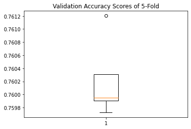

```
Running with hyperparameters: {'batch_size': 100000, 'epochs': 20, 'layers': 3, 'learning_rate': 0.01, 'neurons': 15}
> Accuracy: 75.995, AUC: 63.489
> Accuracy: 75.991, AUC: 63.231
> Accuracy: 76.120, AUC: 65.260
> Accuracy: 75.972, AUC: 64.586
> Accuracy: 76.031, AUC: 64.952
AUC: mean=64.303 std=0.804, n=5
Accuracy: mean=76.022 std=0.053, n=5
```

```
Running with hyperparameters: {'batch_size': 100000, 'epochs': 40, 'layers': 1, 'learning_rate': 0.01, 'neurons': 5}
> Accuracy: 75.995, AUC: 65.969
> Accuracy: 75.991, AUC: 60.480
> Accuracy: 76.120, AUC: 64.035
> Accuracy: 75.972, AUC: 62.757
> Accuracy: 76.031, AUC: 65.140
AUC: mean=63.676 std=1.928, n=5
Accuracy: mean=76.022 std=0.053, n=5
```

```
Running with hyperparameters: {'batch_size': 100000, 'epochs': 40, 'layers': 1, 'learning_rate': 0.01, 'neurons': 10}
> Accuracy: 75.995, AUC: 49.955
> Accuracy: 75.991, AUC: 65.589
> Accuracy: 76.120, AUC: 64.214
> Accuracy: 75.972, AUC: 64.314
> Accuracy: 76.031, AUC: 64.151
AUC: mean=61.645 std=5.869, n=5
Accuracy: mean=76.022 std=0.053, n=5
```

```
Running with hyperparameters: {'batch_size': 100000, 'epochs': 40, 'layers': 1, 'learning_rate': 0.01, 'neurons': 15}
> Accuracy: 75.996, AUC: 63.606
> Accuracy: 75.990, AUC: 64.557
> Accuracy: 76.198, AUC: 66.510
> Accuracy: 75.972, AUC: 65.653
> Accuracy: 76.032, AUC: 64.818
AUC: mean=65.029 std=0.987, n=5
Accuracy: mean=76.037 std=0.082, n=5
```

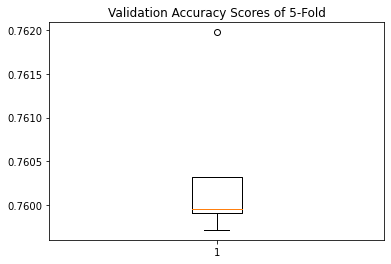

```
Running with hyperparameters: {'batch_size': 100000, 'epochs': 40, 'layers': 2, 'learning_rate': 0.01, 'neurons': 5}
> Accuracy: 75.995, AUC: 64.580
> Accuracy: 75.991, AUC: 50.000
> Accuracy: 76.120, AUC: 64.062
> Accuracy: 75.975, AUC: 65.229
> Accuracy: 76.031, AUC: 64.478
AUC: mean=61.670 std=5.847, n=5
Accuracy: mean=76.022 std=0.052, n=5
```

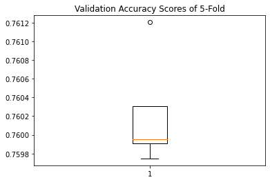

```
Running with hyperparameters: {'batch_size': 100000, 'epochs': 40, 'layers': 2, 'learning_rate': 0.01, 'neurons': 10}
> Accuracy: 75.995, AUC: 65.448
> Accuracy: 75.991, AUC: 65.616
> Accuracy: 76.120, AUC: 64.170
> Accuracy: 75.974, AUC: 66.501
> Accuracy: 76.031, AUC: 50.022
AUC: mean=62.351 std=6.210, n=5
Accuracy: mean=76.022 std=0.052, n=5
```

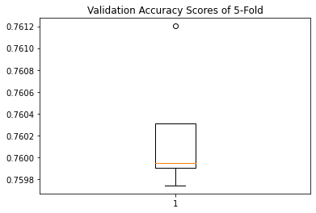

```
Running with hyperparameters: {'batch_size': 100000, 'epochs': 40, 'layers': 2, 'learning_rate': 0.01, 'neurons': 15}
> Accuracy: 75.995, AUC: 64.832
> Accuracy: 75.991, AUC: 64.937
> Accuracy: 76.120, AUC: 65.611
> Accuracy: 75.972, AUC: 64.182
> Accuracy: 76.032, AUC: 65.439
AUC: mean=65.000 std=0.503, n=5
Accuracy: mean=76.022 std=0.053, n=5
```

```
Running with hyperparameters: {'batch_size': 100000, 'epochs': 40, 'layers': 3, 'learning_rate': 0.01, 'neurons': 5}
> Accuracy: 75.995, AUC: 66.328
> Accuracy: 75.991, AUC: 63.973
> Accuracy: 76.120, AUC: 50.000
> Accuracy: 75.972, AUC: 50.001
> Accuracy: 76.032, AUC: 66.298
AUC: mean=59.320 std=7.657, n=5
Accuracy: mean=76.022 std=0.053, n=5
```

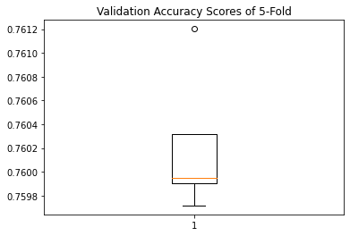

```
Running with hyperparameters: {'batch_size': 100000, 'epochs': 40, 'layers': 3, 'learning_rate': 0.01, 'neurons': 10}
> Accuracy: 75.995, AUC: 63.736
> Accuracy: 75.991, AUC: 66.013
> Accuracy: 76.120, AUC: 64.206
> Accuracy: 75.978, AUC: 66.441
> Accuracy: 76.034, AUC: 64.234
AUC: mean=64.926 std=1.085, n=5
Accuracy: mean=76.024 std=0.052, n=5
```

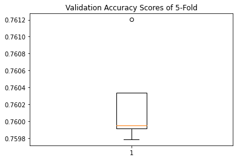

```
Running with hyperparameters: {'batch_size': 100000, 'epochs': 40, 'layers': 3, 'learning_rate': 0.01, 'neurons': 15}
> Accuracy: 76.027, AUC: 66.404
> Accuracy: 75.991, AUC: 50.000
> Accuracy: 76.182, AUC: 66.508
> Accuracy: 75.972, AUC: 65.232
> Accuracy: 76.045, AUC: 66.153
AUC: mean=62.859 std=6.445, n=5
Accuracy: mean=76.043 std=0.074, n=5
```

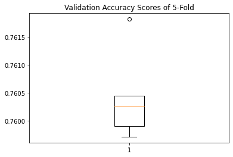

```
Running with hyperparameters: {'batch_size': 100000, 'epochs': 60, 'layers': 1, 'learning_rate': 0.01, 'neurons': 5}
> Accuracy: 75.997, AUC: 56.000
> Accuracy: 75.991, AUC: 64.388
> Accuracy: 76.120, AUC: 64.521
> Accuracy: 75.972, AUC: 66.067
> Accuracy: 76.031, AUC: 64.411
AUC: mean=63.078 std=3.595, n=5
Accuracy: mean=76.022 std=0.053, n=5
```

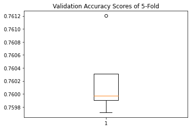

```
Running with hyperparameters: {'batch_size': 100000, 'epochs': 60, 'layers': 1, 'learning_rate': 0.01, 'neurons': 10}
> Accuracy: 75.995, AUC: 65.150
> Accuracy: 75.991, AUC: 65.557
> Accuracy: 76.120, AUC: 64.667
> Accuracy: 75.975, AUC: 64.428
> Accuracy: 76.031, AUC: 65.377
AUC: mean=65.036 std=0.426, n=5
Accuracy: mean=76.022 std=0.052, n=5
```

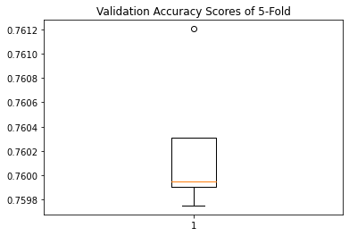

```
Running with hyperparameters: {'batch_size': 100000, 'epochs': 60, 'layers': 1, 'learning_rate': 0.01, 'neurons': 15}
> Accuracy: 75.995, AUC: 66.123
> Accuracy: 76.043, AUC: 65.975
> Accuracy: 76.119, AUC: 66.507
> Accuracy: 75.972, AUC: 66.492
> Accuracy: 76.031, AUC: 63.695
AUC: mean=65.758 std=1.052, n=5
Accuracy: mean=76.032 std=0.050, n=5
```

[27 more figures not shown]

```
Running with hyperparameters: {'batch_size': 500000, 'epochs': 60, 'layers': 3, 'learning_rate': 0.01, 'neurons': 10}
> Accuracy: 75.995, AUC: 63.647
> Accuracy: 75.991, AUC: 65.065
> Accuracy: 76.120, AUC: 61.127
> Accuracy: 75.972, AUC: 63.822
> Accuracy: 76.031, AUC: 62.800
AUC: mean=63.292 std=1.302, n=5
Accuracy: mean=76.022 std=0.053, n=5
```

```
Running with hyperparameters: {'batch_size': 500000, 'epochs': 60, 'layers': 3, 'learning_rate': 0.01, 'neurons': 15}
> Accuracy: 75.995, AUC: 64.740
> Accuracy: 75.991, AUC: 63.988
> Accuracy: 76.120, AUC: 63.702
> Accuracy: 75.972, AUC: 63.457
> Accuracy: 76.031, AUC: 63.574
AUC: mean=63.892 std=0.459, n=5
Accuracy: mean=76.022 std=0.053, n=5
```

```
Best Hyperparameters based on accuracy: {'batch_size': 500000, 'epochs': 60, 'layers': 3, 'learning_rate': 0.01, 'neurons': 15}
Best Hyperparameters based on AUC: {'batch_size': 500000, 'epochs': 60, 'layers': 3, 'learning_rate': 0.01, 'neurons': 15}
```

```python
# Function to define the nn model
def define_model(input_dim, layers, neurons, loss_f, metric, learning_rate):
    model = Sequential()
    model.add(Dense(neurons, input_shape=(input_dim,), activation='relu', kernel_initializer='he_uniform'))

    for _ in range(layers - 1):
        model.add(Dense(neurons, activation='relu', kernel_initializer='he_uniform'))

    model.add(Dense(1, activation='sigmoid'))  # Output - binary
    opt = SGD(learning_rate=learning_rate, momentum=0.9)
    model.compile(optimizer=opt, loss=loss_f, metrics=[metric])
    return model


####_______________________________________________________________________________________________________________________


# Function to evaluate the model using k-fold cross-validation
def evaluate_model(X_train, y_train, n_folds, loss_f, metric, epochs, batch_size, layers, neurons, learning_rate):
    scores, histories, aucs = list(), list(), list()
    kfold = KFold(n_folds, shuffle=True, random_state=1)

    for train_ix, test_ix in kfold.split(X_train):
        trainX, trainY, testX, testY = X_train.iloc[train_ix, :], y_train.iloc[train_ix], X_train.iloc[test_ix, :], y_train.iloc[test_ix]

        # Add Early stop
        early_stop = EarlyStopping(monitor='val_loss', patience=5, restore_best_weights=True)

        model = define_model(X_train.shape[1], layers, neurons, loss_f, metric, learning_rate)

        # Fit model
        history = model.fit(trainX, trainY, epochs=epochs, batch_size=batch_size,
                            validation_data=(testX, testY), verbose=0, callbacks=[early_stop])

        # Evaluate model
        _, acc = model.evaluate(testX, testY, verbose=0)

        # Compute AUC
        y_pred_proba = model.predict(testX, verbose=0)
        auc = roc_auc_score(testY, y_pred_proba)

        print('> Accuracy: %.3f, AUC: %.3f' % (acc * 100.0, auc * 100.0))


        # Append scores
        scores.append(acc)
        aucs.append(auc)
        histories.append(history)

    return scores, aucs, histories, model


####_______________________________________________________________________________________________________________________


# Function to plot diagnostic learning curves
def summarize_diagnostics(histories): #Not used here
    plt.figure(figsize=(15, 5))
    for i in range(len(histories)):
        plt.subplot(311)
        plt.title('Cross Entropy Loss')
        plt.plot(histories[i].history['loss'], color='blue', label='train')
        plt.plot(histories[i].history['val_loss'], color='orange', label='test')
        plt.subplot(312)
        plt.title('Classification Accuracy')
        plt.plot(histories[i].history['accuracy'], color='blue', label='train')
        plt.plot(histories[i].history['val_accuracy'], color='orange', label='test')
    plt.show()


####_______________________________________________________________________________________________________________________


# Function to summarize model performance
def summarize_performance(scores, aucs):
    print('AUC: mean=%.3f std=%.3f, n=%d' % (np.mean(aucs)*100, np.std(aucs)*100, len(aucs)))

    print('Accuracy: mean=%.3f std=%.3f, n=%d' % (np.mean(scores)*100, np.std(scores)*100, len(scores)))

    plt.boxplot(scores)
    plt.title('Validation Accuracy Scores of 5-Fold')
    plt.show()


####_______________________________________________________________________________________________________________________


# Function to run the test harness for evaluating a model
def run_test_harness(X_train, y_train, n_folds, loss_f, metric, epochs, batch_size, layers, neurons, learning_rate):
    scores, aucs, histories, model = evaluate_model(X_train, y_train, n_folds, loss_f, metric,
                                                    epochs, batch_size, layers, neurons, learning_rate)
#     summarize_diagnostics(histories)
    summarize_performance(scores, aucs)
    return scores, aucs


####_______________________________________________________________________________________________________________________


# Example hyperparameter grid for grid search
param_grid = {
    'epochs': [20, 40, 60],
    'batch_size': [100000, 250000, 500000],
    'layers': [1, 2, 3],
    'neurons': [5, 10, 15],
    'learning_rate': [0.01]
}


####_______________________________________________________________________________________________________________________


# Perform grid search
best_score = 0.0
best_auc = 0.0

best_params_acc = None
best_params_auc = None

grid = ParameterGrid(param_grid)
for params in grid:
    print("Running with hyperparameters:", params)
    current_scores, current_aucs = run_test_harness(X_train_resampled, y_train_resampled,
                                                    n_folds=5, loss_f='binary_crossentropy',
                                                    metric='accuracy', **params)

    if np.mean(current_scores) > best_score:
        best_score = np.mean(current_scores)
        best_params_acc = params

    if np.mean(current_aucs) > best_auc:
        best_auc = np.mean(current_aucs)
        best_params_auc = params
```

#### Ignore the two printed statements at the end of the last section, as they were just printing the final tested parameters not the best performing.

```python
print("Best Hyperparameters based on accuracy:", best_params_acc)

print('\nAUC on k-fold validation sets: mean=62.859 std=6.445, n=5 \
\nAccuracy on k-fold validation sets: mean=76.043 std=0.074, n=5\n\n')
```

```
Best Hyperparameters based on accuracy: {'batch_size': 100000, 'epochs': 40, 'layers': 3, 'learning_rate': 0.01, 'neurons': 15}

AUC on k-fold validation sets: mean=62.859 std=6.445, n=5
Accuracy on k-fold validation sets: mean=76.043 std=0.074, n=5
```

```python
print("Best Hyperparameters based on AUC:", best_params_auc)

print('\nAUC on k-fold validation sets: mean=65.922 std=0.394, n=5 \
\nAccuracy on k-fold validation sets: mean=76.024 std=0.053, n=5')
```

```
Best Hyperparameters based on AUC: {'batch_size': 100000, 'epochs': 60, 'layers': 2, 'learning_rate': 0.01, 'neurons': 15}

AUC on k-fold validation sets: mean=65.922 std=0.394, n=5
Accuracy on k-fold validation sets: mean=76.024 std=0.053, n=5
```

**Conclusion**: When we compare the top two sets of hyperparameters—one optimized for accuracy and the other for AUC—we observe a minimal difference in accuracy, just 0.019%. However, the distinction becomes more apparent when we examine AUC. There is a significant gap in both the average AUC and the consistency across the 5 validation folds, as indicated by the higher standard deviation of 6.445 in the best-Accuracy model compared to 0.394 in the best-AUC model. This leads us to favor the model with the highest AUC. Opting for this model provides a substantial improvement in AUC, ensuring more robust performance across various validations. The slight compromise in overall accuracy is overshadowed by the considerable gains in AUC and the heightened confidence in the model's performance.

**Save the best-performance parameters**

```python
import pickle

# Save the dictionary to a file
with open('best_params_auc.pkl', 'wb') as file:
    pickle.dump(best_params_auc, file)
```